# ZEAL Prolificacy (Prolif) GWAS + JLM on the SNP50K panel — 1000-permutation FWER

- Show All Code
- Hide All Code
- View Source

The prolificacy analog of the EN notebook: same SNP50K ancestry pipeline, phenotype = per-field SpATS prolificacy BLUEs, candidate set = the curated maize ear-number / prolificacy cloned-gene panel (core gt1/tb1/tru1 + inflorescence-architecture branching/meristem/KRN genes). Significance is a genome-wide FWER from a 1000-permutation null (per scan): the Manhattan line is the −log₁₀P exceeded by only 5% of permutations, and candidate/peak calls report whether they clear it.

Author

Fausto Rodríguez-Zapata

Published

July 16, 2026

**What this is.** The prolificacy (Prolif) sibling of `zeal-qtl-recovery-en-mlm-snp50k`, built from the same real ZEAL pipeline end-to-end: field Prolif → SpATS spatial BLUEs → SNP50K teosinte-ancestry dosage → RTIGER ancestry mosaic → K → JLM + MLM. The population is the same near-isogenic B73×teosinte BC2S3 lines from **5 teosinte taxa**. Prolif is **prolificacy** — the propensity to bear more than one ear — and the per-genotype value is the per-field SpATS mean across the two fields (CLY23-D4, CLY25-B5). It shares the ear-number candidate panel with the `ear-number (EN)` notebook; only the phenotype changes.

**ImportantGenotype at 0.4× skim: why ancestry, not per-SNP**

SNP50K is 51,991 teosinte-vs-B73 sites pileup-genotyped at ~0.4× — hard genotypes are unusable (70% missing, ~0% hom-ALT), so ancestry is inferred from the per-sample allele **counts**. The **per-SNP genotype (bcftools HWE-posterior) (Panel B)** is therefore λ_GC-deflated (sparse mean-imputation); the **RTIGER ancestry mosaic (Panel C)** is the usable, block-smoothed genotype (teosinte presence 0.111, matching the established BzeaSeq ~0.101). This is the SNP50K-specific reason ancestry inference is mandatory, and is identical to the DTA/PH/EH/EN notebooks — only the phenotype changes.

**Trait context.** Prolificacy — bearing multiple ears rather than a single dominant ear — is the domestication axis most directly opposed between teosinte and B73: teosinte’s long, branched lateral architecture produces many ears, while the maize apical-dominance program concentrates resources into one or two. Prolif and ear number (EN) are two scorings of the same underlying axillary-meristem-fate biology and share the candidate panel: the **core regulators** `gt1` (*grassy tillers1*, the **prol1.1** QTL gene — teosinte allele derepresses axillary ear buds → prolific ears), `tb1` (*teosinte branched1*, the *Hopscotch*-driven apical-dominance domestication locus), and `tru1` (*tassels replace upper ears1*, a tb1 target for ear-vs-tassel identity); plus the second-tier **inflorescence-architecture / meristem / KRN** genes (`ub2`/`ub3`, `ra1`/`ra2`/`ra3`, `fea2`/`fea3`/`td1`). Because teosinte ancestry is broadly prolificacy-increasing and **partly collinear with K**, the mixed model absorbs ancestry-correlated variance, and the model-independent **JLM** (nested-in-family stepwise) is the primary QTL tool — with `gt1`/`tb1` the two loci most likely to surface as headline, effect-bearing QTL.

```r
library(here)
library(data.table)
library(ggplot2)
library(fastman)
library(ggrepel)
library(ggtext)
library(scales)
library(cowplot)
source(here("scripts/teonam_notebook_plots.R")) # shared: plot_manhattan/lollipop, lambda_gc, LOD
```

```r
mlm <- fread(here("data/zeal/prolif_gwas_mlm_rtiger_mosaic_donor_accession_snp50k.csv")) # Panel C
gt <- fread(here("data/zeal/prolif_gwas_mlm_hwe_post_gt_donor_accession_snp50k.csv")) # Panel B
ols <- fread(here("data/zeal/prolif_gwas_ols_donor_accession_snp50k.csv"))[is.finite(P) & P > 0]
overlap <- here("results/sim/zeal/prolif_candidate_overlap.csv")
lam <- function(p) {
  p <- p[is.finite(p) & p > 0 & p <= 1]
  round(median(qchisq(p, 1, lower.tail = FALSE)) / qchisq(0.5, 1), 2)
}
# Significance = genome-wide FWER from a 1000-permutation null (scripts/zeal_gwas_perm.R),
# stored per (trait, model, geno) in data/zeal/gwas_perm_thresholds.csv.
TR <- "PROLIF"
thr <- function(model, geno, a = 0.05) gwas_thr(TR, model, geno, a)
thr_ols <- thr("ols", "rtiger_mosaic")
thr_mlm <- thr("mlm", "rtiger_mosaic")
thr_gt <- thr("mlm", "hwe_post_gt")
nsig <- function(p, t) sum(-log10(p) > t, na.rm = TRUE)
```

**NoteSignificance = 1000-permutation genome-wide FWER (5%)**

Every Manhattan’s dotted line is the **−log₁₀P exceeded by only 5% of 1000 permutations** of that scan (a genome-wide max-−log₁₀P null; `scripts/zeal_gwas_perm.R`), stored per (trait, model, geno) in `data/zeal/gwas_perm_thresholds.csv`. A marker is significant iff its −log₁₀P clears that line. The line’s height differs per panel with the null. Candidate/peak tables report whether the marker clears the 5% FWER line.

## Candidate gene registry

Curated evidence for each **candidate** (tier, causal direction, evidence type, phenotype, and a DOI link) from the tracked registry (`reference/candidate_genes.csv` × `candidate_evidence.csv`). These are the genes starred on the Manhattans and labelled on the lollipop; loci without B73 v5 coordinates still appear here but are not plotted.

```r
candidate_table(TR)
```

Candidate genes for PROLIF from the tracked registry (reference/candidate_*.csv): 12 loci (12 mapped to B73 v5, 0 unmapped). DOI links where curated; “TODO” = evidence not yet curated.

| gene | full name | locus | tier | direction | evidence | phenotype / note | reference |
| --- | --- | --- | --- | --- | --- | --- | --- |
| *gt1* | grassy tillers1 | 1:23.4 Mb | 1 - ear number / prolificacy (core) |  |  | Ear number / prolificacy — underlies the prol1.1 QTL; represses growth of axillary ear buds. Repressed by shade; teosinte allele → prolific tillers/ears. | 10.1073/pnas.1102819108 |
| *ub2* | unbranched2 | 1:192.4 Mb | 2 - inflorescence architecture (branching / meristem / KRN) |  |  | Inflorescence branching / kernel row number — tassel branch & ear row number. | 10.1073/pnas.1407401112 |
| *tb1* | teosinte branched1 | 1:272.3 Mb | 1 - ear number / prolificacy (core) |  |  | Ear number / prolificacy — suppresses axillary branching; Hopscotch insertion upstream drives apical dominance & reduced ear number. Major domestication locus. | 10.1038/386485a0 |
| *abi17* | ABI3-VP1-transcription factor 17 | 2:49.4 Mb | 3 - chr2 positional candidate |  |  | Ear number / prolificacy — chr2 positional candidate (abi17, MaizeGDB). Browser/MaizeMine ‘Auxin response factor’ auto-annotation is a B3-domain artifact. | MaizeGDB (Zm00001eb082150 = abi17); positional candidate under chr2 QTL |
| *ra2* | ramosa2 | 3:12.8 Mb | 2 - inflorescence architecture (branching / meristem / KRN) |  |  | Inflorescence branching — meristem determinacy in ear/tassel. | 10.1105/tpc.105.039032 |
| *fea3* | fasciated ear3 | 3:29.2 Mb | 2 - inflorescence architecture (branching / meristem / KRN) |  |  | Ear meristem size / kernel row number — CLE-peptide signalling. | 10.1038/ng.3567 |
| *tru1* | tassels replace upper ears1 | 3:152.1 Mb | 1 - ear number / prolificacy (core) |  |  | Ear number / prolificacy — direct target of tb1; promotes ear (vs tassel) identity in axillary meristems. Loss → tassels replace upper ears. | 10.1073/pnas.1714960114 |
| *fea2* | fasciated ear2 | 4:138.7 Mb | 2 - inflorescence architecture (branching / meristem / KRN) |  |  | Ear meristem size / kernel row & ear fasciation — CLV-WUS pathway. | 10.1101/gad.208501 |
| *ub3* | unbranched3 | 4:205.4 Mb | 2 - inflorescence architecture (branching / meristem / KRN) |  |  | Inflorescence branching / kernel row number — paralog of ub2. | 10.1073/pnas.1407401112 |
| *td1* | thick tassel dwarf1 | 5:63.5 Mb | 2 - inflorescence architecture (branching / meristem / KRN) |  |  | Ear/tassel meristem size — CLV-WUS pathway; kernel row number. | 10.1242/dev.01671 |
| *ra1* | ramosa1 | 7:115.0 Mb | 2 - inflorescence architecture (branching / meristem / KRN) |  |  | Inflorescence branching — restricts long-branch (spikelet-pair) formation; affects ear/tassel branch number. | 10.1038/nature03892 |
| *ra3* | ramosa3 | 7:176.0 Mb | 2 - inflorescence architecture (branching / meristem / KRN) |  |  | Inflorescence branching — meristem determinacy; sugar signalling. | 10.1038/nature04725 |

## Candidate genes: closest marker vs window-max marker

For each maize ear-number / prolificacy candidate (B73 v5), the closest marker to the gene body vs the highest −log₁₀P marker within ±500 kb in the RTIGER-mosaic **MLM (Family+K)** scan (Panel C). Candidates are the curated cloned ear-number / prolificacy panel (core `gt1`/`tb1`/`tru1` + inflorescence-architecture branching/meristem/KRN genes; v5 coordinates); `pathway` records the tier and protein/role each acts in.

```r
sc <- copy(mlm)[is.finite(P) & P > 0][, logP := -log10(P)]
gg <- fread(here("data/teonam/prolif_candidate_genes.tsv"))
gg[, chr := as.integer(chr)][, qtl := ifelse(qtl_chen2019 == "" | is.na(qtl_chen2019), paste0("PROLIF(chr", chr, ")"), qtl_chen2019)]
WIN <- 5e5
ctab <- rbindlist(lapply(seq_len(nrow(gg)), function(i) {
  ch <- gg$chr[i]
  s <- gg$start[i]
  e <- gg$end[i]
  m <- sc[CHR == ch]
  if (!nrow(m)) {
    return(NULL)
  }
  d <- pmax(0L, pmax(s - m$BP, m$BP - e))
  kc <- which.min(d)
  w <- m[BP >= s - WIN & BP <= e + WIN]
  kw <- if (nrow(w)) which.max(w$logP) else NA
  data.table(
    gene = gg$symbol[i], pathway = gg$pathway[i], chr = ch, `gene start (v5)` = s,
    `closest Δstart (bp)` = m$BP[kc] - s, `closest -log10P` = round(m$logP[kc], 2),
    `window-max -log10P` = if (nrow(w)) round(w$logP[kw], 2) else NA_real_,
    `clears perm 5%` = if (nrow(w)) (w$logP[kw] >= thr_mlm) else NA
  )
}))
setorder(ctab, chr, `gene start (v5)`)
knitr::kable(ctab,
  format.args = list(big.mark = ","),
  caption = sprintf("Prolif candidates (B73 v5; curated maize ear-number / prolificacy panel): closest vs window-max (±500 kb) marker, RTIGER-mosaic MLM (Family+K) scan; 'clears perm 5%%' = window-max exceeds the 1000-permutation FWER line (-log10P = %.2f).", thr_mlm)
)
```

Prolif candidates (B73 v5; curated maize ear-number / prolificacy panel): closest vs window-max (±500 kb) marker, RTIGER-mosaic MLM (Family+K) scan; ‘clears perm 5%’ = window-max exceeds the 1000-permutation FWER line (-log10P = 4.53).

| gene | pathway | chr | gene start (v5) | closest Δstart (bp) | closest -log10P | window-max -log10P | clears perm 5% |
| --- | --- | --- | --- | --- | --- | --- | --- |
| gt1 | Ear number / prolificacy — underlies the prol1.1 QTL; represses growth of axillary ear buds. Repressed by shade; teosinte allele → prolific tillers/ears. | 1 | 23,433,554 | -1,058 | 2.99 | 4.48 | FALSE |
| ub2 | Inflorescence branching / kernel row number — tassel branch & ear row number. | 1 | 192,381,440 | -101,208 | 0.85 | 1.09 | FALSE |
| tb1 | Ear number / prolificacy — suppresses axillary branching; Hopscotch insertion upstream drives apical dominance & reduced ear number. Major domestication locus. | 1 | 272,330,564 | -40,634 | 0.04 | 0.30 | FALSE |
| abi17 | Ear number / prolificacy — chr2 positional candidate (abi17, MaizeGDB). Browser/MaizeMine ‘Auxin response factor’ auto-annotation is a B3-domain artifact. | 2 | 49,388,328 | 2,821 | 0.33 | 0.41 | FALSE |
| ra2 | Inflorescence branching — meristem determinacy in ear/tassel. | 3 | 12,830,057 | 7,984 | 1.53 | 1.92 | FALSE |
| fea3 | Ear meristem size / kernel row number — CLE-peptide signalling. | 3 | 29,213,107 | -40,521 | 0.78 | 1.43 | FALSE |
| tru1 | Ear number / prolificacy — direct target of tb1; promotes ear (vs tassel) identity in axillary meristems. Loss → tassels replace upper ears. | 3 | 152,086,191 | -7,157 | 0.41 | 1.00 | FALSE |
| fea2 | Ear meristem size / kernel row & ear fasciation — CLV-WUS pathway. | 4 | 138,680,814 | -5,446 | 1.04 | 1.04 | FALSE |
| ub3 | Inflorescence branching / kernel row number — paralog of ub2. | 4 | 205,414,194 | 13,112 | 0.75 | 0.75 | FALSE |
| td1 | Ear/tassel meristem size — CLV-WUS pathway; kernel row number. | 5 | 63,488,542 | -1,077 | 0.77 | 0.77 | FALSE |
| ra1 | Inflorescence branching — restricts long-branch (spikelet-pair) formation; affects ear/tassel branch number. | 7 | 114,958,643 | 29,660 | 0.44 | 0.95 | FALSE |
| ra3 | Inflorescence branching — meristem determinacy; sugar signalling. | 7 | 175,982,697 | 3,277 | 0.71 | 1.45 | FALSE |

## OLS → MLM: structure control

Here **Family** is the **82 donor-accession** fixed factor (parent-plant-level structure correction) that the MLM and per-marker OLS scans were actually computed with — a stronger correction than the 5 donor **taxa** the JLM nests on. It likely over-corrects population structure and costs some power; a taxon-level (5) MLM/OLS rerun is a pending comparison (see `TERMINOLOGY.md`).

The fixed-effect OLS (Family + marker, no K) vs the MLM (Family + K) on the RTIGER mosaic, same fixed part. OLS is intrinsically inflated (ancestry-block LD, unfixable by any fixed factor); K deflates λ toward 1 and removes the ancestry-correlated bulk that a near-isogenic, teosinte-ancestry-structured prolificacy panel carries.

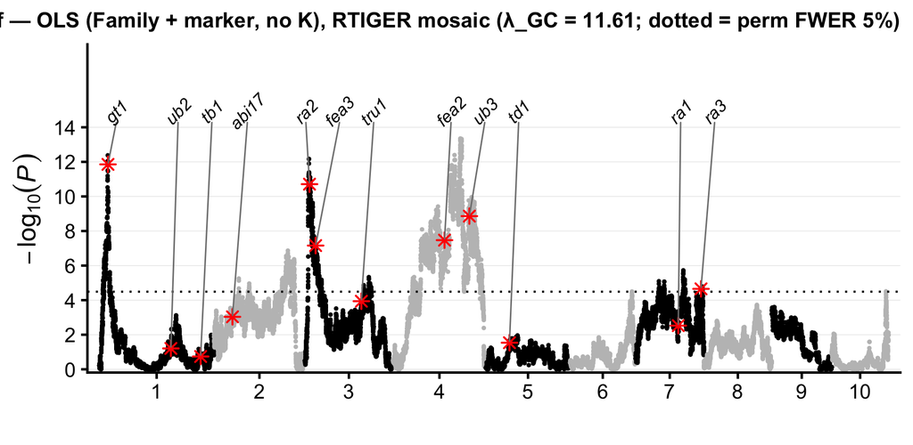

```r
plot_manhattan(ols,
  sprintf("ZEAL Prolif — OLS (Family + marker, no K), RTIGER mosaic (λ_GC = %.2f; dotted = perm FWER 5%%)", lam(ols$P)),
  overlap_csv = overlap, lod = thr_ols,
  out_png = here("results/sim/zeal/prolif_gwas_ols_manhattan_fdr_snp50k.png")
)
```

The OLS Manhattan (no K) is genome-wide inflated (ancestry-block LD) — the same structure artifact the MLM K term removes below.

```r
lam_tab <- data.table(
  model = c("OLS (Family + marker, no K)", "MLM (Family + K)"),
  markers = c(nrow(ols), nrow(mlm)),
  lambda_GC = c(lam(ols$P), lam(mlm$P)),
  `n > perm 5%` = c(nsig(ols$P, thr_ols), nsig(mlm$P, thr_mlm)),
  max_logP = round(c(max(-log10(ols$P)), max(-log10(mlm$P))), 2)
)
knitr::kable(lam_tab, caption = "OLS vs MLM on the RTIGER mosaic (same Family fixed part): K deflates genomic inflation; n markers above each scan's 1000-permutation 5% FWER line.")
```

OLS vs MLM on the RTIGER mosaic (same Family fixed part): K deflates genomic inflation; n markers above each scan’s 1000-permutation 5% FWER line.

| model | markers | lambda_GC | n > perm 5% | max_logP |
| --- | --- | --- | --- | --- |
| OLS (Family + marker, no K) | 48900 | 11.61 | 5955 | 13.35 |
| MLM (Family + K) | 48900 | 1.09 | 9 | 5.14 |

```r
ov <- fread(overlap)
peak_at <- function(scan, ch, s) {
  w <- scan[CHR == ch & abs(BP - s) <= 5e5 & is.finite(P) & P > 0]
  if (!nrow(w)) NA_real_ else round(max(-log10(w$P)), 2)
}
cmp <- ov[, .(
  gene = symbol, chr,
  `OLS peak` = mapply(peak_at, list(ols), chr, start),
  `MLM peak` = mapply(peak_at, list(mlm), chr, start)
)]
cmp[, `drop (OLS−MLM)` := round(`OLS peak` - `MLM peak`, 2)]
setorder(cmp, -`OLS peak`)
knitr::kable(cmp, caption = "Local peak -log10P (±500 kb) per candidate: OLS vs MLM. K suppresses the ancestry-collinear prolificacy signal.")
```

Local peak -log10P (±500 kb) per candidate: OLS vs MLM. K suppresses the ancestry-collinear prolificacy signal.

| gene | chr | OLS peak | MLM peak | drop (OLS−MLM) |
| --- | --- | --- | --- | --- |
| gt1 | 1 | 11.86 | 4.48 | 7.38 |
| ra2 | 3 | 10.71 | 1.92 | 8.79 |
| ub3 | 4 | 8.86 | 0.75 | 8.11 |
| fea2 | 4 | 7.47 | 1.04 | 6.43 |
| fea3 | 3 | 7.16 | 1.43 | 5.73 |
| ra3 | 7 | 4.65 | 1.45 | 3.20 |
| tru1 | 3 | 3.94 | 1.00 | 2.94 |
| abi17 | 2 | 3.04 | 0.41 | 2.63 |
| ra1 | 7 | 2.53 | 0.95 | 1.58 |
| td1 | 5 | 1.54 | 0.77 | 0.77 |
| ub2 | 1 | 1.21 | 1.09 | 0.12 |
| tb1 | 1 | 0.74 | 0.30 | 0.44 |

## JLM QTL genomic distribution (Panel A)

Prolif QTL from JLM (TASSEL StepwiseOLS, nested in taxon, entry by a 1000-permutation empirical α = 0.05 (Chen-style genome-wide FWER; per-trait)). JLM QTL are selected by the stepwise enter/exit P (a model-selection gate), independent of the per-scan permutation FWER line used for the GWAS Manhattans below. Model-independent — the primary Prolif analysis, as in Chen 2019.

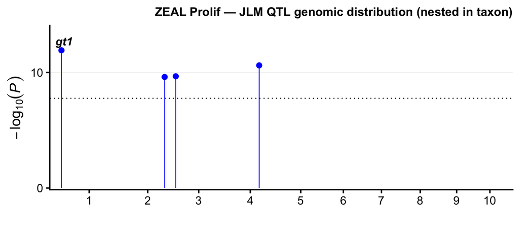

```r
p_lolli <- plot_lollipop(
  here("results/sim/zeal/tassel/prolif_jlm_native1.txt"), mlm,
  "ZEAL Prolif — JLM QTL genomic distribution (nested in taxon)",
  overlap_csv = overlap,
  out_png = here("results/sim/zeal/prolif_jlm_lollipop_snp50k.png")
)
p_lolli
```

## MLM (Family + K), RTIGER ancestry mosaic (Panel C)

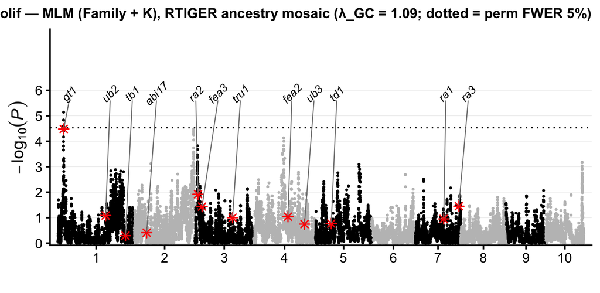

```r
p_mlm <- plot_manhattan(mlm,
  sprintf("ZEAL Prolif — MLM (Family + K), RTIGER ancestry mosaic (λ_GC = %.2f; dotted = perm FWER 5%%)", lam(mlm$P)),
  overlap_csv = overlap, lod = thr_mlm, out_png = here("results/sim/zeal/prolif_gwas_mlm_rtiger_mosaic_manhattan_fdr_snp50k.png")
)
p_mlm
```

```r
cat(sprintf("%d markers clear the 5%% FWER line (-log10P = %.2f)\n", nsig(mlm$P, thr_mlm), thr_mlm))
```

```
9 markers clear the 5% FWER line (-log10P = 4.53)
```

## Composite (A: JLM · B: per-SNP MLM · C: RTIGER-mosaic MLM)

Panel B (per-SNP genotype (bcftools HWE-posterior)) is λ_GC-deflated — the 70%-missing per-SNP panel at 0.4× is sparse — but catches sharp SNP hits the mosaic block-terraces away. Panel C (the ancestry mosaic) is the usable, well-calibrated genotype. The B↔︎C contrast is the notebook’s per-SNP-scatter vs ancestry-block-smoothing, and the demonstration that ancestry inference is mandatory at low coverage — identical in mechanism to the DTA/PH/EH/EN notebooks.

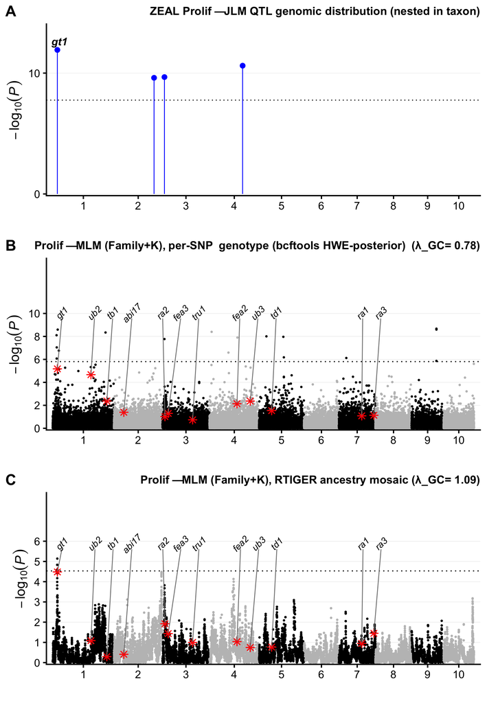

```r
p_B <- plot_manhattan(gt,
  sprintf("Prolif — MLM (Family+K), per-SNP genotype (bcftools HWE-posterior) (λ_GC = %.2f)", lam(gt$P)),
  overlap_csv = overlap, lod = thr_gt
)
p_C <- plot_manhattan(mlm,
  sprintf("Prolif — MLM (Family+K), RTIGER ancestry mosaic (λ_GC = %.2f)", lam(mlm$P)),
  overlap_csv = overlap, lod = thr_mlm
)
composite <- cowplot::plot_grid(p_lolli, p_B, p_C, ncol = 1, labels = c("A", "B", "C"), label_size = 20, align = "v", axis = "lr")
ggsave(here("results/sim/zeal/prolif_composite_snp50k.png"), composite, width = 9, height = 13, dpi = 200, bg = "white")
composite
```

## Multi-caller Prolif scan (control · nNIL · RTIGER · LB-Impute · binhmm)

The same Prolif MLM (Family+K) scan on each ancestry caller’s recovered genotypes, at the real ~0.4× depth (not a coverage sweep). The robust, trait-independent finding is **teosinte-presence recovery**: the block/bin-aggregated callers (RTIGER 0.111; binhmm 0.101) recover the established BzeaSeq fraction (~0.10), while per-SNP calling (control) and the per-SNP HMM recalls (nNIL, LB-Impute) **under-call**. Genomic inflation is phenotype-dependent (reported per caller below). Caller genotypes are population-level and trait-independent; only the phenotype (Prolif) changes.

```r
callers <- c(control = "hwe_post_gt", nNIL = "nnil_mosaic", RTIGER = "rtiger_mosaic", `LB-Impute` = "lbimpute_mosaic", binhmm = "binhmm_mosaic")
gg <- fread(here("data/teonam/prolif_candidate_genes.tsv"))[, chr := as.integer(chr)]
# best (max -log10P) Prolif candidate window per caller
max_cand_logp <- function(sc) {
  lp <- -log10(sc$P)
  vals <- unlist(lapply(seq_len(nrow(gg)), function(i) {
    idx <- which(sc$CHR == gg$chr[i] & abs(sc$BP - gg$start[i]) <= 5e5)
    if (length(idx)) max(lp[idx], na.rm = TRUE) else NA_real_
  }))
  if (all(is.na(vals))) NA_real_ else round(max(vals, na.rm = TRUE), 2)
}
ctab2 <- rbindlist(lapply(names(callers), function(nm) {
  g <- callers[[nm]]
  sc <- fread(here(sprintf("data/zeal/prolif_gwas_mlm_%s_donor_accession_snp50k.csv", g)))
  mf <- here(sprintf("data/zeal/zeal_%s.rds", g))
  pres <- if (file.exists(mf)) {
    st <- readRDS(mf)$state
    round(mean(st %in% c(1L, 2L), na.rm = TRUE), 3)
  } else {
    NA_real_
  }
  sc <- sc[is.finite(P) & P > 0]
  data.table(
    caller = nm, `teosinte presence` = pres, lambda_GC = lam(sc$P),
    `n > perm 5%` = nsig(sc$P, gwas_thr(TR, "mlm", g)),
    `best candidate -log10P` = max_cand_logp(sc)
  )
}))
knitr::kable(ctab2, caption = "Prolif MLM (Family+K) by ancestry caller at 0.4×, with n markers above the caller's own 1000-permutation 5% FWER line and the best (max) -log10P across the ear-number / prolificacy candidate windows.")
```

Prolif MLM (Family+K) by ancestry caller at 0.4×, with n markers above the caller’s own 1000-permutation 5% FWER line and the best (max) -log10P across the ear-number / prolificacy candidate windows.

| caller | teosinte presence | lambda_GC | n > perm 5% | best candidate -log10P |
| --- | --- | --- | --- | --- |
| control | 0.008 | 0.78 | 17 | 5.17 |
| nNIL | 0.018 | 0.83 | 3 | 6.67 |
| RTIGER | 0.111 | 1.09 | 9 | 4.48 |
| LB-Impute | 0.035 | 0.90 | 154 | 2.56 |
| binhmm | 0.101 | 0.86 | 0 | 3.27 |

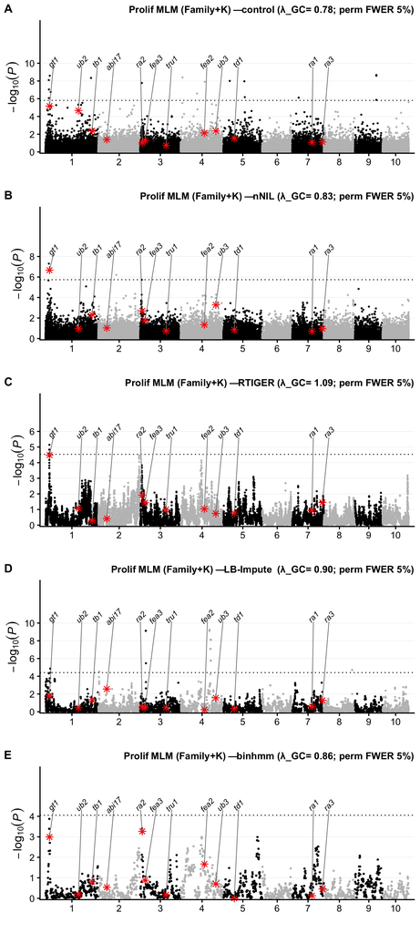

```r
panels <- lapply(names(callers), function(nm) {
  sc <- fread(here(sprintf("data/zeal/prolif_gwas_mlm_%s_donor_accession_snp50k.csv", callers[[nm]])))
  plot_manhattan(sc, sprintf("Prolif MLM (Family+K) — %s (λ_GC = %.2f; perm FWER 5%%)", nm, lam(sc$P)), overlap_csv = overlap, lod = gwas_thr(TR, "mlm", callers[[nm]]))
})
cc <- cowplot::plot_grid(plotlist = panels, ncol = 1, labels = LETTERS[1:5], label_size = 18, align = "v", axis = "lr")
ggsave(here("results/sim/zeal/prolif_caller_composite_fdr_snp50k.png"), cc, width = 9, height = 20, dpi = 200, bg = "white")
cc
```